# MTH6139 Time Series

Coursework 1 – Template

Spring term 2025

```r
knitr::opts_chunk$set(echo = TRUE)

library(prophet)
library(jsonlite)
library(ggplot2)
library(dplyr)
library(zoo)
library(lubridate)
```

# Section 1: Project Purpose

This project analyses the monthly Wikipedia pageviews for the article **Bitcoin**. It was motivated by the interest that my family and friends have in the “future of finance”. The aim is to study how public interest in Bitcoin has changed over time, identify any recurring patterns, and build a forecasting model using Meta’s Prophet system.

Wikipedia pageviews are a useful proxy for public attention because they measure how often users search for information about a topic. In the case of Bitcoin, pageviews may rise during periods of strong media coverage, major market movements, or wider public debate about cryptocurrencies.

# Section 2: Download and Prepare the Data

```r
get_monthly_wikipedia_pageviews <- function(article_name = "Bitcoin",
                                            project_name = "en.wikipedia.org",
                                            access_type = "all-access",
                                            agent_type = "all-agents",
                                            start_date = "20150701",
                                            end_date = format(Sys.Date(), "%Y%m%d")) {

  encoded_article_name <- utils::URLencode(article_name, reserved = TRUE)

  request_url <- paste0(
    "https://wikimedia.org/api/rest_v1/metrics/pageviews/per-article/",
    project_name, "/",
    access_type, "/",
    agent_type, "/",
    encoded_article_name, "/monthly/",
    start_date, "/",
    end_date
  )

  connection_object <- url(
    request_url,
    headers = c("User-Agent" = "MTH6139-Time-Series-Coursework/1.0")
  )

  raw_response <- readLines(connection_object, warn = FALSE)
  close(connection_object)

  parsed_response <- jsonlite::fromJSON(paste(raw_response, collapse = ""))

  monthly_pageviews <- data.frame(
    ds = as.Date(paste0(substr(parsed_response$items$timestamp, 1, 6), "01"),
                 format = "%Y%m%d"),
    y = parsed_response$items$views
  )

  monthly_pageviews
}

bitcoin_pageviews_monthly <- get_monthly_wikipedia_pageviews()

# Remove the current incomplete month if present
bitcoin_pageviews_monthly <- bitcoin_pageviews_monthly %>%
  filter(ds < floor_date(Sys.Date(), unit = "month"))

head(bitcoin_pageviews_monthly)
```

```
##           ds      y
## 1 2015-07-01 274264
## 2 2015-08-01 288091
## 3 2015-09-01 280885
## 4 2015-10-01 273249
## 5 2015-11-01 297821
## 6 2015-12-01 387384
```

```r
tail(bitcoin_pageviews_monthly)
```

```
##             ds      y
## 123 2025-09-01 204516
## 124 2025-10-01 287314
## 125 2025-11-01 300087
## 126 2025-12-01 258864
## 127 2026-01-01 219334
## 128 2026-02-01 270563
```

The dataset contains two variables:

- `ds`: the month
- `y`: the total number of pageviews in that month

```r
dir.create("data", showWarnings = FALSE)

write.csv(
  bitcoin_pageviews_monthly,
  "data/bitcoin_wikipedia_pageviews_monthly.csv",
  row.names = FALSE
)
```

# Section 3: Data

```r
dim(bitcoin_pageviews_monthly)
```

```
## [1] 128   2
```

```r
summary(bitcoin_pageviews_monthly$y)
```

```
##    Min. 1st Qu.  Median    Mean 3rd Qu.    Max.
##  189023  274310  329046  482608  503833 4934888
```

```r
sum(is.na(bitcoin_pageviews_monthly$y))
```

```
## [1] 0
```

```r
min(bitcoin_pageviews_monthly$ds)
```

```
## [1] "2015-07-01"
```

```r
max(bitcoin_pageviews_monthly$ds)
```

```
## [1] "2026-02-01"
```

This gives a basic check of the size of the dataset, the range of monthly pageviews, whether there are any missing values, and the time span covered.

## 3.1 Monthly Time Series Plot

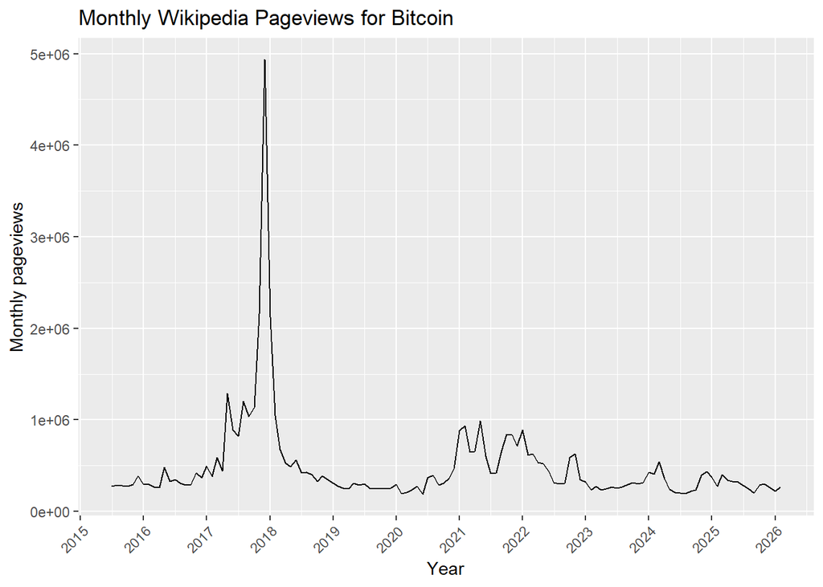

```r
ggplot(bitcoin_pageviews_monthly, aes(x = ds, y = y)) +
  geom_line(linewidth = 0.4) +
  scale_x_date(
    date_breaks = "1 year",
    date_labels = "%Y",
    limits = c(min(bitcoin_pageviews_monthly$ds), max(bitcoin_pageviews_monthly$ds))
  ) +
  labs(
    title = "Monthly Wikipedia Pageviews for Bitcoin",
    x = "Year",
    y = "Monthly pageviews"
  ) +
  theme(axis.text.x = element_text(angle = 45, hjust = 1))
```

```r
peak_month <- bitcoin_pageviews_monthly[which.max(bitcoin_pageviews_monthly$y), ]
peak_month
```

```
##            ds       y
## 30 2017-12-01 4934888
```

```r
cat(
  "Peak month:", format(peak_month$ds, "%B %Y"), "\n",
  "Peak pageviews:", format(peak_month$y, big.mark = ",")
)
```

```
## Peak month: December 2017
##  Peak pageviews: 4,934,888
```

## 3.2 Largest Monthly Spikes

```r
largest_monthly_spikes <- bitcoin_pageviews_monthly %>%
  arrange(desc(y)) %>%
  slice(1:10)

largest_monthly_spikes
```

```
##            ds       y
## 1  2017-12-01 4934888
## 2  2017-11-01 2161074
## 3  2018-01-01 2123189
## 4  2017-05-01 1288638
## 5  2017-08-01 1201415
## 6  2017-10-01 1133857
## 7  2018-02-01 1049435
## 8  2017-09-01 1033029
## 9  2021-05-01  990438
## 10 2021-02-01  933565
```

This table shows the ten months with the highest number of Bitcoin pageviews. Most of the largest spikes occur around 2017 and early 2018, which suggests that this was the period of greatest public interest in Bitcoin.

# Section 4: Trend Analysis

To better understand the general movement in the series, I add a smoothed trend line.

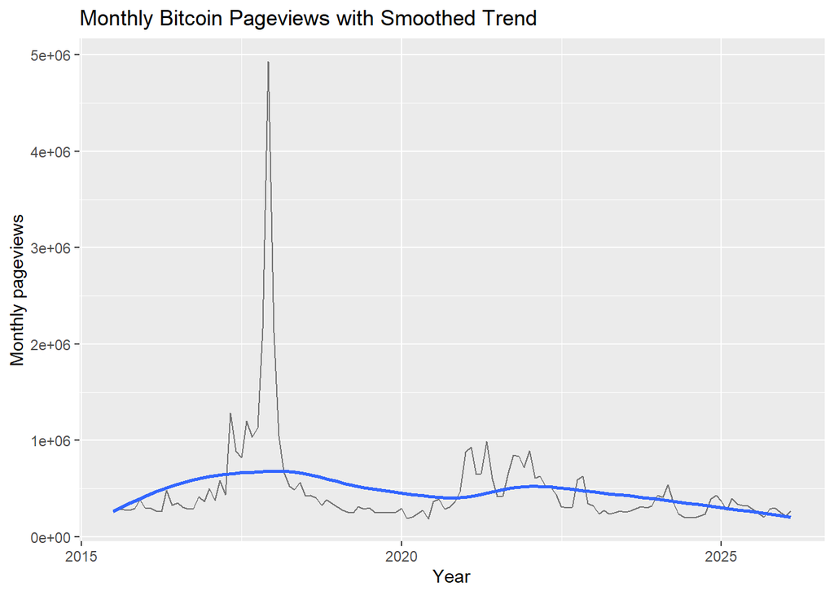

```r
ggplot(bitcoin_pageviews_monthly, aes(x = ds, y = y)) +
  geom_line(alpha = 0.5) +
  geom_smooth(se = FALSE) +
  labs(
    title = "Monthly Bitcoin Pageviews with Smoothed Trend",
    x = "Year",
    y = "Monthly pageviews"
  )
```

This graph shows the monthly number of Wikipedia pageviews for Bitcoin together with a smoothed trend line. The series is highly volatile, with a very large spike in late 2017, showing a massive surge in public interest. After this peak, attention fell sharply, although there was another smaller rise around 2021. Overall, the smoothed trend suggests that interest in Bitcoin rose rapidly in the earlier years, reached a maximum during the 2017 boom, and then gradually declined, with temporary increases in later periods.

# Section 5: Time Series Decomposition

Monthly data is suitable for decomposition because it may contain long-term movement, seasonality, and random variation.

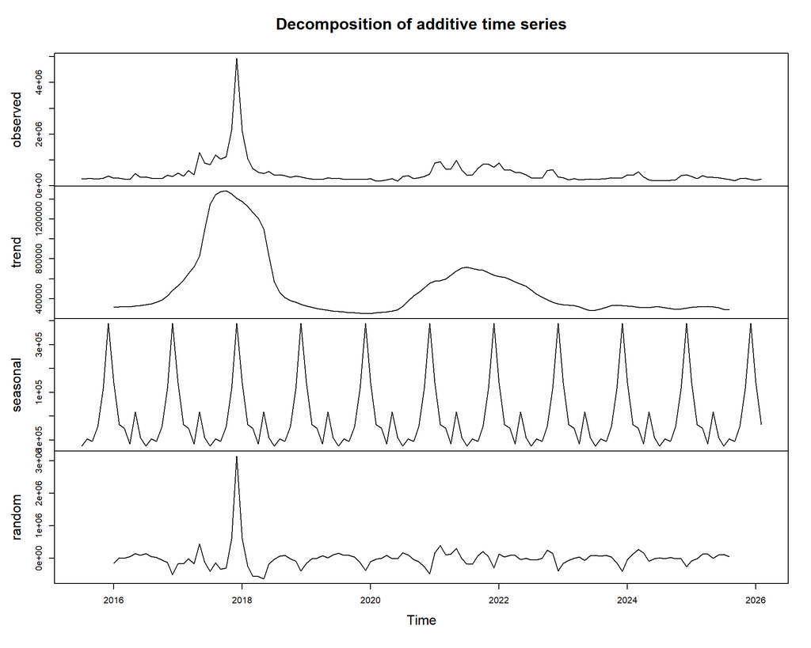

```r
start_year <- year(min(bitcoin_pageviews_monthly$ds))
start_month <- month(min(bitcoin_pageviews_monthly$ds))

bitcoin_monthly_ts <- ts(
  bitcoin_pageviews_monthly$y,
  start = c(start_year, start_month),
  frequency = 12
)

bitcoin_monthly_decomposition <- decompose(bitcoin_monthly_ts)

plot(bitcoin_monthly_decomposition)
```

The decomposition separates the series into:

- observed data
- trend
- seasonal component
- random component

The decomposition plot shows that monthly Bitcoin Wikipedia pageviews were highly volatile over the sample period, with the observed series dominated by a very large spike in late 2017 and smaller increases around 2021–2022. The trend component suggests that public interest in Bitcoin rose sharply up to 2017, declined afterwards, experienced a more moderate recovery around 2021, and then gradually fell again toward the end of the period. The seasonal component indicates that there may be some recurring within-year pattern, but this appears much less important than the large event-driven surges in attention. The random component also highlights that the late-2017 spike was unusually extreme and not fully explained by the underlying trend or seasonality, suggesting that Bitcoin pageviews are influenced not only by regular patterns but also by sudden shocks linked to major news or market developments.

# Section 6: Prophet Forecasting Model

I now fit a Prophet model to the monthly pageviews data.

```r
bitcoin_monthly_prophet_model <- prophet(
  bitcoin_pageviews_monthly,
  yearly.seasonality = TRUE,
  weekly.seasonality = FALSE,
  daily.seasonality = FALSE
)
```

## 6.1 Forecasting the Next 12 Months

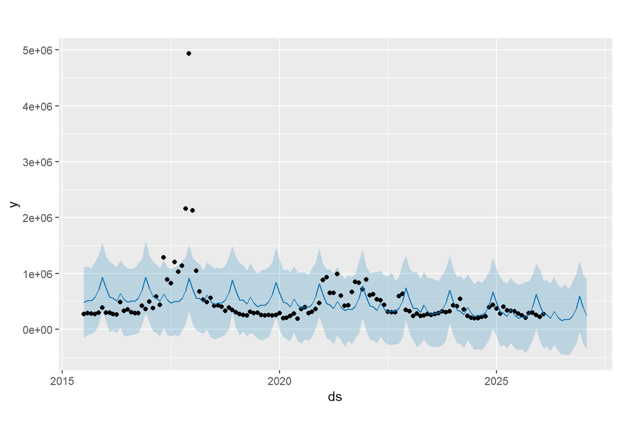

```r
bitcoin_monthly_future_dates <- make_future_dataframe(
  bitcoin_monthly_prophet_model,
  periods = 12,
  freq = "month"
)

bitcoin_monthly_forecast <- predict(
  bitcoin_monthly_prophet_model,
  bitcoin_monthly_future_dates
)

plot(bitcoin_monthly_prophet_model, bitcoin_monthly_forecast)
```

## 6.2 Forecast Components

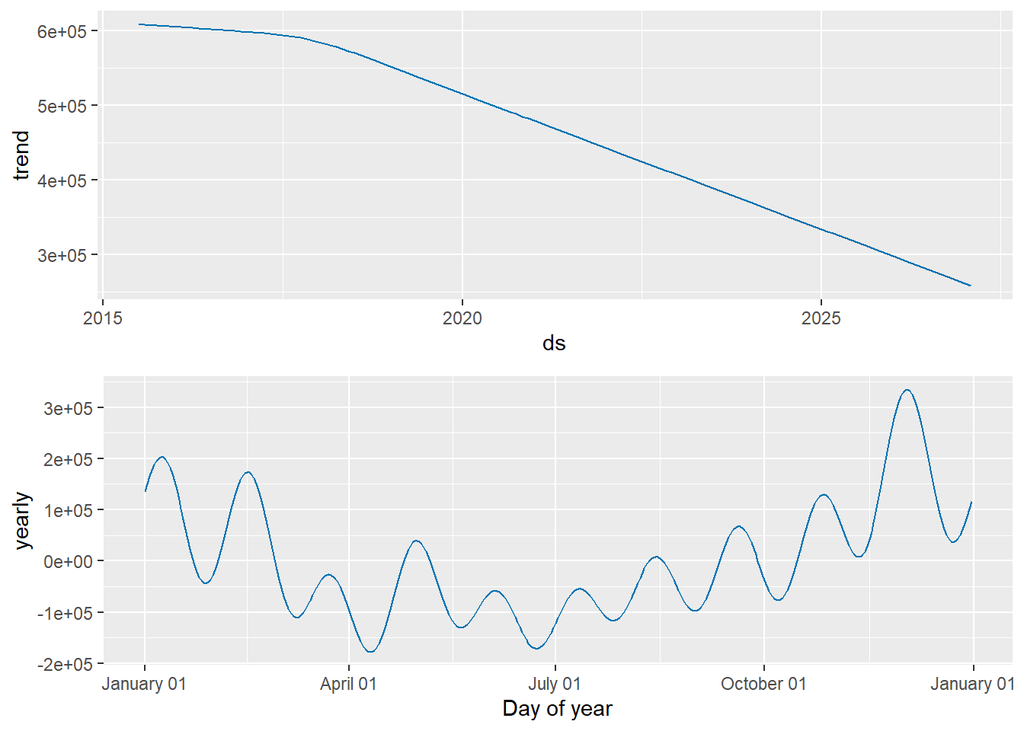

```r
prophet_plot_components(bitcoin_monthly_prophet_model, bitcoin_monthly_forecast)
```

The components plot shows that the Prophet model identifies a clear downward long-term trend in Bitcoin Wikipedia pageviews, meaning public interest has generally fallen over time after the earlier peak period. It also shows some yearly seasonal variation, with certain parts of the year having slightly higher or lower pageviews. However, this seasonal effect is much smaller than the large spikes in the original data, suggesting that Bitcoin pageviews are driven more by major news and market events than by stable seasonal patterns.

# Section 7: Looking at a Shorter Time Frame

It is also useful to inspect the most recent part of the series separately.

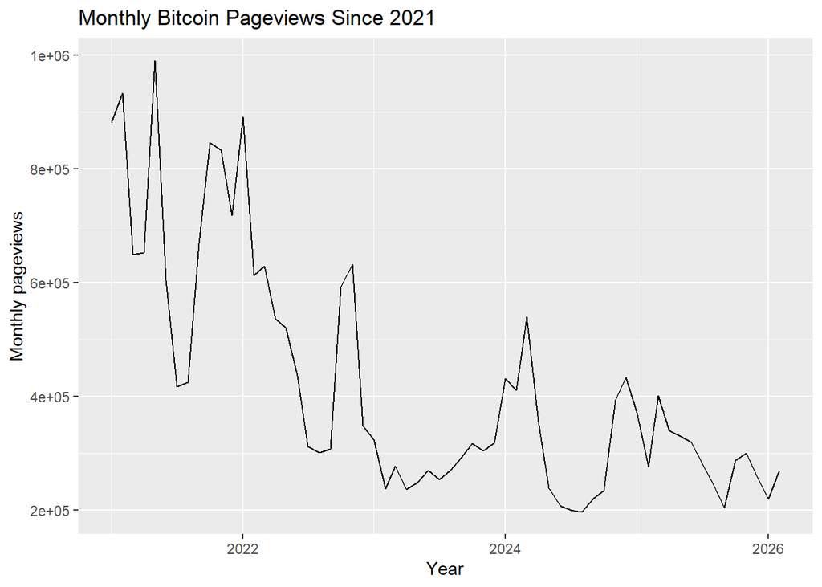

```r
recent_bitcoin_pageviews_monthly <- bitcoin_pageviews_monthly %>%
  filter(ds >= as.Date("2021-01-01"))

ggplot(recent_bitcoin_pageviews_monthly, aes(x = ds, y = y)) +
  geom_line() +
  labs(
    title = "Monthly Bitcoin Pageviews Since 2021",
    x = "Year",
    y = "Monthly pageviews"
  )
```

This shorter view makes recent patterns easier to see. The general theme is the same in that the monthly pageviews have gone down and while there are occasional spikes they are due to some market news the overall public interest in Bitcoin has gone down.

# Section 8: Conclusion

This project analysed monthly Wikipedia pageviews for the article Bitcoin as a measure of public attention.  
The time series showed that interest in Bitcoin changes substantially over time, with some months attracting far more pageviews than others.

The decomposition and Prophet model were used to study the structure of the series and forecast future values.

In conclusion, Bitcoin pageviews provide an interesting example of a modern time series linked to technology, finance, and public interest.

# References

- Wikimedia Pageviews API: https://wikimedia.org/api/rest_v1/
- Meta Prophet forecasting system: https://facebook.github.io/prophet/